# Chapter 5: Dimensionality reduction techniques

## Introduction

In this chapter I will wrangle and analyse data from UNs Development programs Human Development Index (HDI) and Gender Inequality Index data frames. These are combined together to be a data frame named “Human”. More about the data frame here: [UN development programs: HDI](http://hdr.undp.org/en/content/human-development-index-hdi)

```
## 'data.frame':    155 obs. of  9 variables:
##  $ X        : Factor w/ 155 levels "Afghanistan",..: 105 6 134 41 101 54 67 149 28 102 ...
##  $ Edu2.FM  : num  1.007 0.997 0.983 0.989 0.969 ...
##  $ Labo.FM  : num  0.891 0.819 0.825 0.884 0.829 ...
##  $ Life.Exp : num  81.6 82.4 83 80.2 81.6 80.9 80.9 79.1 82 81.8 ...
##  $ Edu.Exp  : num  17.5 20.2 15.8 18.7 17.9 16.5 18.6 16.5 15.9 19.2 ...
##  $ GNI      : Factor w/ 155 levels "1,123","1,228",..: 132 109 124 112 113 111 103 123 108 93 ...
##  $ Mat.Mor  : int  4 6 6 5 6 7 9 28 11 8 ...
##  $ Ado.Birth: num  7.8 12.1 1.9 5.1 6.2 3.8 8.2 31 14.5 25.3 ...
##  $ Parli.F  : num  39.6 30.5 28.5 38 36.9 36.9 19.9 19.4 28.2 31.4 ...
```

```
## [1] 155   9
```

```
## [1] "X"         "Edu2.FM"   "Labo.FM"   "Life.Exp"  "Edu.Exp"   "GNI"
## [7] "Mat.Mor"   "Ado.Birth" "Parli.F"
```

The structure of the frame shows the 9 variables of this frame. The variables in this data frame have been chosen in the data wrangling excercise. X is the row names that are the names of the countries.

```
##            X          Edu2.FM          Labo.FM          Life.Exp
##  Afghanistan:  1   Min.   :0.1717   Min.   :0.1857   Min.   :49.00
##  Albania    :  1   1st Qu.:0.7264   1st Qu.:0.5984   1st Qu.:66.30
##  Algeria    :  1   Median :0.9375   Median :0.7535   Median :74.20
##  Argentina  :  1   Mean   :0.8529   Mean   :0.7074   Mean   :71.65
##  Armenia    :  1   3rd Qu.:0.9968   3rd Qu.:0.8535   3rd Qu.:77.25
##  Australia  :  1   Max.   :1.4967   Max.   :1.0380   Max.   :83.50
##  (Other)    :149
##     Edu.Exp           GNI         Mat.Mor         Ado.Birth
##  Min.   : 5.40   1,123  :  1   Min.   :   1.0   Min.   :  0.60
##  1st Qu.:11.25   1,228  :  1   1st Qu.:  11.5   1st Qu.: 12.65
##  Median :13.50   1,428  :  1   Median :  49.0   Median : 33.60
##  Mean   :13.18   1,458  :  1   Mean   : 149.1   Mean   : 47.16
##  3rd Qu.:15.20   1,507  :  1   3rd Qu.: 190.0   3rd Qu.: 71.95
##  Max.   :20.20   1,583  :  1   Max.   :1100.0   Max.   :204.80
##                  (Other):149
##     Parli.F
##  Min.   : 0.00
##  1st Qu.:12.40
##  Median :19.30
##  Mean   :20.91
##  3rd Qu.:27.95
##  Max.   :57.50
##
```

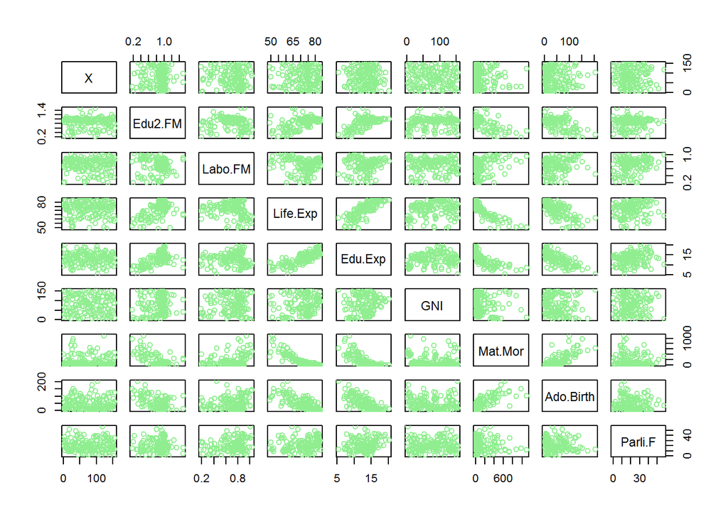

The summary of the variables shows the types of data they hold in. X is as described just a list of country names. Edu2FM is the ratio of secondary education and Labo.FM ratio of labour force participation wrangled in previous exercise. Life Exp shows the life expectancy in different nations where on average people live approximately 71 years. Expected years of education (Edu.exp) shows that in minimum people go to school for is 5 years.

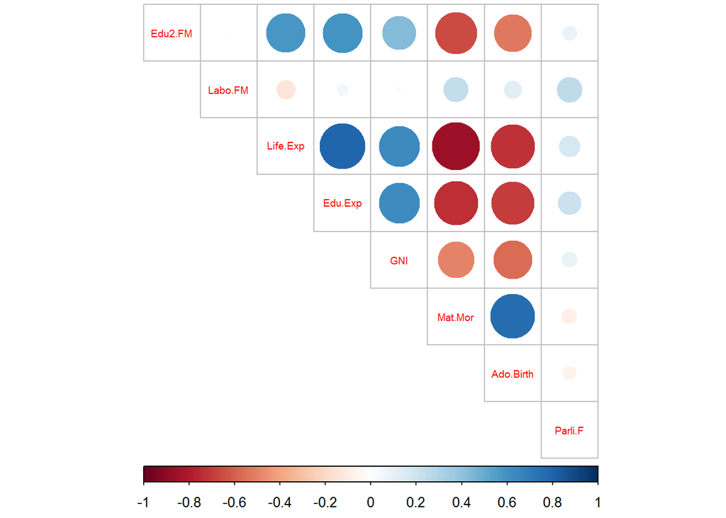

The correlation plot shows that there are strong correlations between the variables. In this graph clearly life expectancy and expected years of education correlate positively.

## Principal component analysis (PCA)

To perform PCA on the data frame, I have to first modify the data frame to make it numeric. First turn GNI into numeric form instead of factor and then remove column X from the data frame, since it contains string formed names. This has been already done for the correlation matrix in previous paragraph.

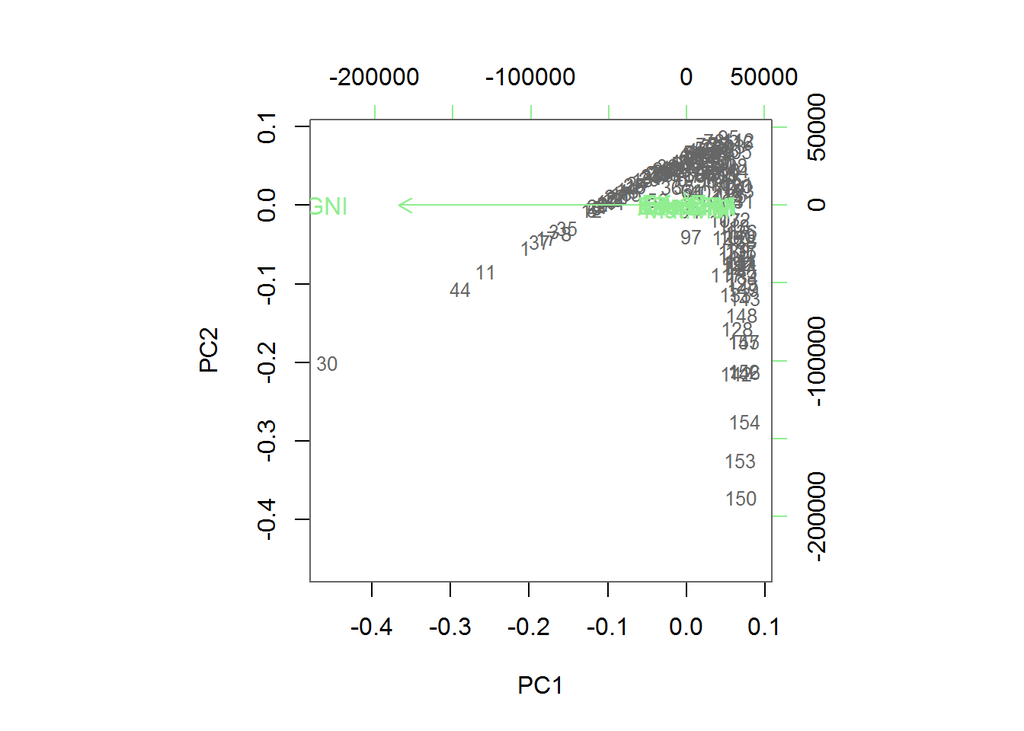

Above here is the biplot of data frame after PCA. The frame has not been standardized yet, which is why it has a strange shape. PCA maximizes the variance between variables and therefore without standardizing they tend to pack tightly or show only observations of one variable clearly. Some more information about why standardizing is needed are here: [Why do we need to normalize data before analysis?](http://stats.stackexchange.com/questions/69157/why-do-we-need-to-normalize-data-before-analysis)

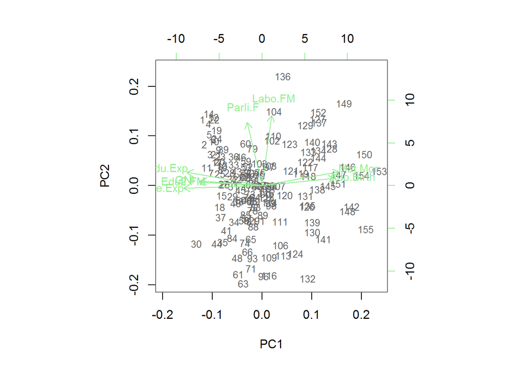

## Multiple correspondence analysis (MCA)

In this last part I loaded another dataset “tea” from FactoMineR- library to perform another dimension reduction technique, Multiple Correspondence analysis (MCA in short). This set contains answers from poll on things related to tea time. The structure and the dimensions of the data frame can be seen from below.

```
## 'data.frame':    300 obs. of  36 variables:
##  $ breakfast       : Factor w/ 2 levels "breakfast","Not.breakfast": 1 1 2 2 1 2 1 2 1 1 ...
##  $ tea.time        : Factor w/ 2 levels "Not.tea time",..: 1 1 2 1 1 1 2 2 2 1 ...
##  $ evening         : Factor w/ 2 levels "evening","Not.evening": 2 2 1 2 1 2 2 1 2 1 ...
##  $ lunch           : Factor w/ 2 levels "lunch","Not.lunch": 2 2 2 2 2 2 2 2 2 2 ...
##  $ dinner          : Factor w/ 2 levels "dinner","Not.dinner": 2 2 1 1 2 1 2 2 2 2 ...
##  $ always          : Factor w/ 2 levels "always","Not.always": 2 2 2 2 1 2 2 2 2 2 ...
##  $ home            : Factor w/ 2 levels "home","Not.home": 1 1 1 1 1 1 1 1 1 1 ...
##  $ work            : Factor w/ 2 levels "Not.work","work": 1 1 2 1 1 1 1 1 1 1 ...
##  $ tearoom         : Factor w/ 2 levels "Not.tearoom",..: 1 1 1 1 1 1 1 1 1 2 ...
##  $ friends         : Factor w/ 2 levels "friends","Not.friends": 2 2 1 2 2 2 1 2 2 2 ...
##  $ resto           : Factor w/ 2 levels "Not.resto","resto": 1 1 2 1 1 1 1 1 1 1 ...
##  $ pub             : Factor w/ 2 levels "Not.pub","pub": 1 1 1 1 1 1 1 1 1 1 ...
##  $ Tea             : Factor w/ 3 levels "black","Earl Grey",..: 1 1 2 2 2 2 2 1 2 1 ...
##  $ How             : Factor w/ 4 levels "alone","lemon",..: 1 3 1 1 1 1 1 3 3 1 ...
```

[output cut: 22 more lines]

```
## [1] 300  36
```

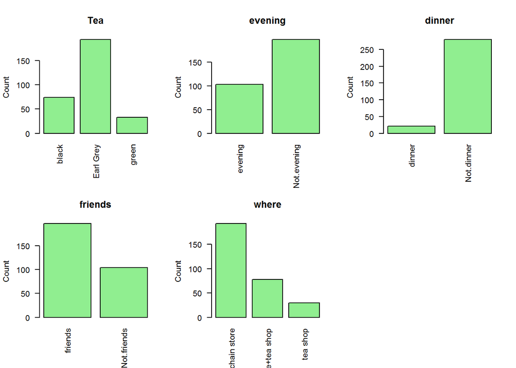

To perform MCA, I choose variables Tea, Evening, Dinner, Friends and Where.

```
##
## Call:
## MCA(X = tea_time, graph = FALSE)
##
##
## Eigenvalues
##                        Dim.1   Dim.2   Dim.3   Dim.4   Dim.5   Dim.6
## Variance               0.286   0.235   0.204   0.201   0.180   0.152
## % of var.             20.401  16.790  14.599  14.391  12.889  10.842
## Cumulative % of var.  20.401  37.191  51.790  66.181  79.070  89.913
##                        Dim.7
## Variance               0.141
## % of var.             10.087
## Cumulative % of var. 100.000
##
## Individuals (the 10 first)
##                Dim.1    ctr   cos2    Dim.2    ctr   cos2    Dim.3    ctr
## 1           |  0.492  0.283  0.199 | -0.834  0.986  0.570 |  0.459  0.344
## 2           |  0.492  0.283  0.199 | -0.834  0.986  0.570 |  0.459  0.344
## 3           |  0.062  0.004  0.001 |  0.912  1.179  0.247 | -0.556  0.505
## 4           |  0.881  0.905  0.231 |  0.405  0.232  0.049 | -0.527  0.453
## 5           | -0.019  0.000  0.000 | -0.388  0.214  0.151 | -0.420  0.287
## 6           |  0.881  0.905  0.231 |  0.405  0.232  0.049 | -0.527  0.453
## 7           | -0.160  0.030  0.057 | -0.064  0.006  0.009 | -0.388  0.246
## 8           |  0.154  0.028  0.016 | -0.743  0.782  0.368 |  0.429  0.300
## 9           | -0.046  0.002  0.002 | -0.111  0.017  0.010 |  0.119  0.023
## 10          | -0.213  0.053  0.023 | -0.374  0.198  0.072 |  0.938  1.434
##               cos2
## 1            0.173 |
## 2            0.173 |
## 3            0.092 |
## 4            0.083 |
## 5            0.176 |
## 6            0.083 |
## 7            0.336 |
## 8            0.123 |
## 9            0.012 |
## 10           0.450 |
##
## Categories (the 10 first)
```

[output cut: 15 more lines]

```
## evening       1.817 |  -0.045   0.068   0.001  -0.561 |
## Not.evening  -1.817 |   0.023   0.035   0.001   0.561 |
## dinner        9.457 |  -0.290   0.576   0.006  -1.376 |
## Not.dinner   -9.457 |   0.022   0.043   0.006   1.376 |
## friends       8.290 |   0.001   0.000   0.000   0.020 |
## Not.friends  -8.290 |  -0.002   0.000   0.000  -0.020 |
## chain store -10.269 |  -0.437  11.936   0.339 -10.065 |
##
## Categorical variables (eta2)
##               Dim.1 Dim.2 Dim.3
## Tea         | 0.351 0.172 0.672 |
## evening     | 0.185 0.011 0.001 |
## dinner      | 0.146 0.299 0.006 |
## friends     | 0.373 0.230 0.000 |
## where       | 0.373 0.463 0.343 |
```

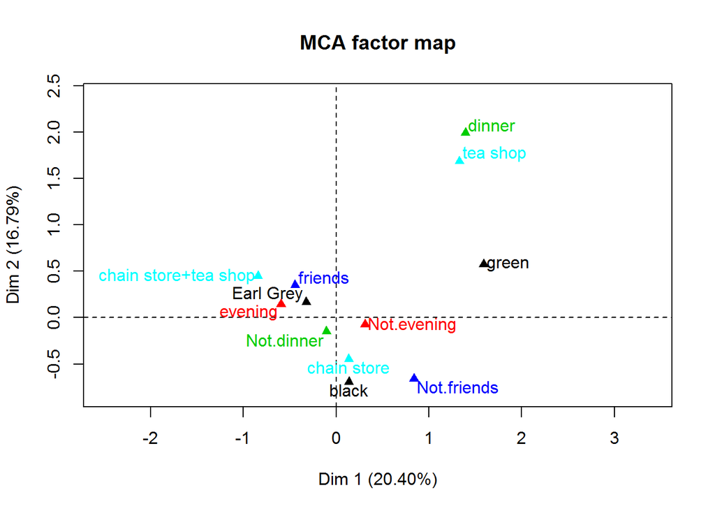

Clearly three variables stand from the crowd: dinner, tea shop and green tea. They do not come close to the dimensions and dinner and tea shop even correlate with each other. All the other variables gather around the origo of dimension values and do not oppse any particular dimension.